# Trends in Student Number over time by Gunagwera Alex

## Original Ratio plots for all the for years

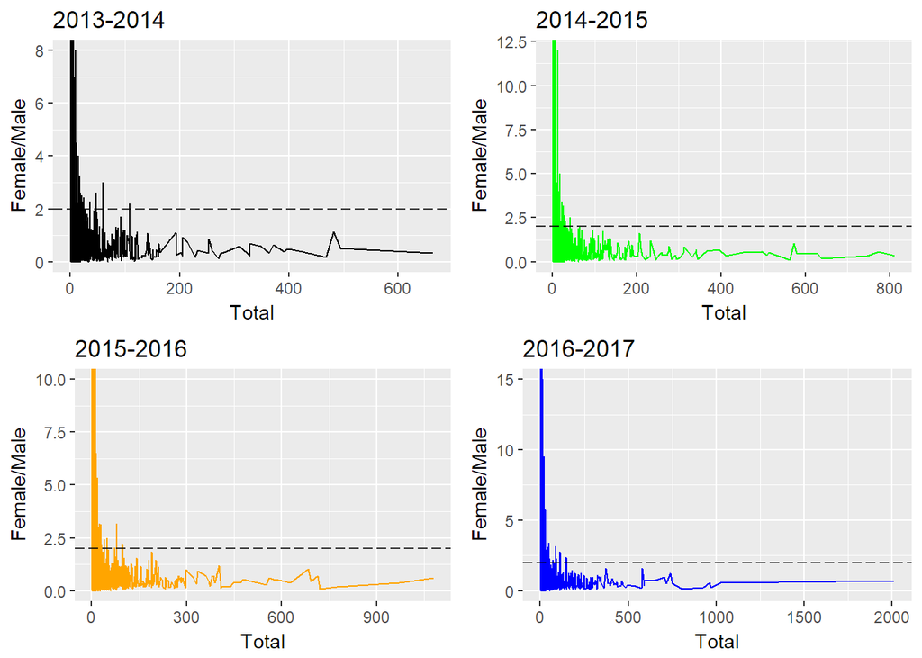

```r
p1 = ggplot(data = f1314Totaless, aes(x = Total, y = Female / Male)) +
  geom_line() +
  geom_hline(yintercept = 2, alpha = 0.8, linetype = 5) +
  ggtitle("2013-2014")

p2 = ggplot(data = f1415Totaless, aes(x = Total, y = Female / Male)) +
  geom_line(colour = "green") +
  geom_hline(yintercept = 2, alpha = 0.8, linetype = 5) +
  ggtitle("2014-2015")

p3 = ggplot(data = f1516Totaless, aes(x = Total, y = Female / Male)) +
  geom_line(colour = "orange") +
  geom_hline(yintercept = 2, alpha = 0.8, linetype = 5) +
  ggtitle("2015-2016")

p4 = ggplot(data = f1617Totaless, aes(x = Total, y = Female / Male)) +
  geom_line(colour = "blue") +
  geom_hline(yintercept = 2, alpha = 0.8, linetype = 5) +
  ggtitle("2016-2017")

library(gridExtra)
grid.arrange(p1, p2, p3, p4, nrow = 2)
```

## Scaled log10 Ratio plots for all the for years

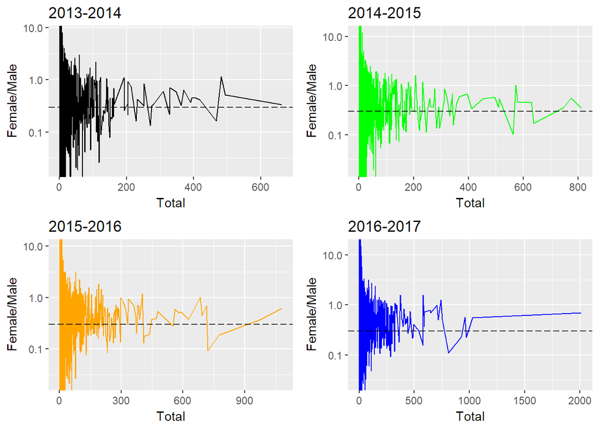

```r
p1 = ggplot(data = f1314Totaless, aes(x = Total, y = Female / Male)) +
  geom_line() +
  scale_y_log10()+
  geom_hline(yintercept = 0.3, alpha = 0.8, linetype = 5) +
  ggtitle("2013-2014")

p2 = ggplot(data = f1415Totaless, aes(x = Total, y = Female / Male)) +
  geom_line(colour = "green") +
  scale_y_log10()+
  geom_hline(yintercept = 0.3, alpha = 0.8, linetype = 5) +
  ggtitle("2014-2015")

p3 = ggplot(data = f1516Totaless, aes(x = Total, y = Female / Male)) +
  geom_line(colour = "orange") +
  scale_y_log10()+
  geom_hline(yintercept = 0.3, alpha = 0.8, linetype = 5) +
  ggtitle("2015-2016")

p4 = ggplot(data = f1617Totaless, aes(x = Total, y = Female / Male)) +
  geom_line(colour = "blue") +
  scale_y_log10()+
  geom_hline(yintercept = 0.3, alpha = 0.8, linetype = 5) +
  ggtitle("2016-2017")

library(gridExtra)
grid.arrange(p1, p2, p3, p4, nrow = 2)
```

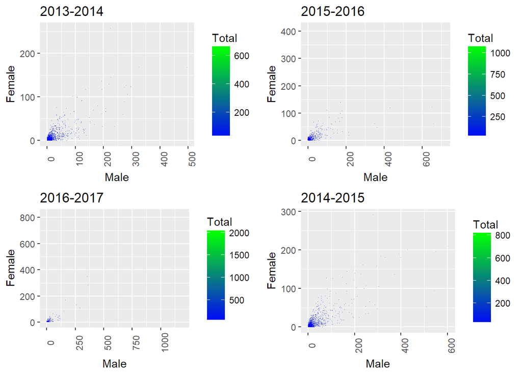

```r
p1 = ggplot(aes(y = Female, x = Male, fill = Total),
  data = f1314Totaless) +
  geom_tile() +
  scale_fill_gradientn(colours = colorRampPalette(c("blue", "green"))(10)) +
  ggtitle("2013-2014")+
  theme(axis.text.x = element_text(angle = 90))

p2 = ggplot(aes(y = Female, x = Male, fill = Total),
  data = f1516Totaless) +
  geom_tile() +
  scale_fill_gradientn(colours = colorRampPalette(c("blue", "green"))(10))+
  ggtitle("2015-2016")+
  theme(axis.text.x = element_text(angle = 90))

p3 = ggplot(aes(y = Female, x = Male, fill = Total),
  data = f1617Totaless) +
  geom_tile() +
  scale_fill_gradientn(colours = colorRampPalette(c("blue", "green"))(10))+
  ggtitle("2016-2017")+
  theme(axis.text.x = element_text(angle = 90))

p4 = ggplot(aes(y = Female, x = Male, fill = Total),
  data = f1415Totaless) +
  geom_tile() +
  scale_fill_gradientn(colours = colorRampPalette(c("blue", "green"))(10))+
  ggtitle("2014-2015")+
  theme(axis.text.x = element_text(angle = 90))
library(gridExtra)
grid.arrange(p1, p2, p3, p4, nrow = 2)
```

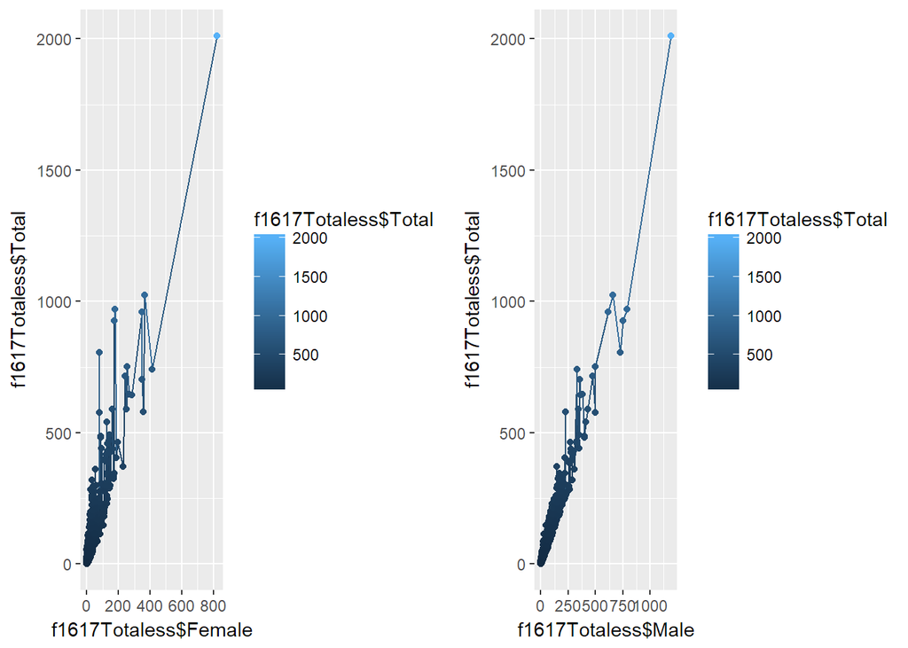

```r
p1 =ggplot(data=f1617Totaless, aes(x=f1617Totaless$Female, y=f1617Totaless$Total,
                               colour=f1617Totaless$Total)) +
  geom_line() +
  geom_point()

p2 =ggplot(data=f1617Totaless, aes(x=f1617Totaless$Male, y=f1617Totaless$Total,
                               colour=f1617Totaless$Total)) +
  geom_line() +
  geom_point()
grid.arrange(p1, p2, ncol = 2)
```

# A linear modal to predict the total

```r
library(memisc)
m1 <- lm(I(log(Total)) ~ I(NatIonalIty), data = f1617Totaless)
m2 <- update(m1, ~ . + NatIonalIty)
m3 <- update(m2, ~ . + CIty)
m4 <- update(m3, ~ . + UnIversIty)
m5 <- update(m4, ~ . + Female)
m6 <- update(m5, ~ . + Male)
m7 <- update(m6, ~ . + Type)

mtable(m1, m2, m3, m4, m5, m6, m7)
```

```
##
## Calls:
## m1: lm(formula = I(log(Total)) ~ I(NatIonalIty), data = f1617Totaless)
## m2: lm(formula = I(log(Total)) ~ I(NatIonalIty) + NatIonalIty, data = f1617Totaless)
## m3: lm(formula = I(log(Total)) ~ I(NatIonalIty) + NatIonalIty + CIty,
##     data = f1617Totaless)
## m4: lm(formula = I(log(Total)) ~ I(NatIonalIty) + NatIonalIty + CIty +
##     UnIversIty, data = f1617Totaless)
## m5: lm(formula = I(log(Total)) ~ I(NatIonalIty) + NatIonalIty + CIty +
##     UnIversIty + Female, data = f1617Totaless)
## m6: lm(formula = I(log(Total)) ~ I(NatIonalIty) + NatIonalIty + CIty +
##     UnIversIty + Female + Male, data = f1617Totaless)
## m7: lm(formula = I(log(Total)) ~ I(NatIonalIty) + NatIonalIty + CIty +
##     UnIversIty + Female + Male + Type, data = f1617Totaless)
##
## ==================================================================================================================================================================================
##                                                                                   m1             m2             m3             m4            m5            m6            m7
## ----------------------------------------------------------------------------------------------------------------------------------------------------------------------------------
##   (Intercept)                                                                     1.122***       1.122***       0.850***      0.734***      0.745***      0.739***      0.739***
##                                                                                  (0.158)        (0.158)        (0.202)       (0.169)       (0.154)       (0.151)       (0.151)
##   I(NatIonalIty): Ã‡EK /Ã‡AD                                                     -1.064**       -1.064**       -1.161***     -1.118***     -1.121***     -1.093***     -1.093***
##                                                                                  (0.366)        (0.366)        (0.349)       (0.292)       (0.267)       (0.261)       (0.261)
##   I(NatIonalIty): Ã‡IN HALK /Ã‡AD                                                 0.638**        0.638**        0.678***      0.877***      0.699***      0.750***      0.750***
##                                                                                  (0.198)        (0.198)        (0.189)       (0.158)       (0.144)       (0.141)       (0.141)
##   I(NatIonalIty): Ã‡IN TAYVAN/Ã‡AD                                               -0.615         -0.615         -0.779*       -1.252***     -1.184***     -1.147***     -1.147***
##                                                                                  (0.412)        (0.412)        (0.392)       (0.328)       (0.299)       (0.293)       (0.293)
##   I(NatIonalIty): AFGANISTAN ISLAM /Ã‡AD                                          1.578***       1.578***       1.755***      2.072***      1.896***      1.668***      1.668***
##                                                                                  (0.189)        (0.189)        (0.180)       (0.150)       (0.137)       (0.135)       (0.135)
##   I(NatIonalIty): ALMANYA FEDERAL /Ã‡AD                                           1.181***       1.181***       1.337***      1.743***      1.338***      1.477***      1.477***
##                                                                                  (0.187)        (0.187)        (0.178)       (0.149)       (0.136)       (0.133)       (0.133)
##   I(NatIonalIty): AMERIKA BIRLESIK DEVLETLERI/Ã‡AD                               -0.005         -0.005         -0.002         0.245         0.173         0.195         0.195
##                                                                                  (0.203)        (0.203)        (0.194)       (0.162)       (0.148)       (0.145)       (0.145)
##   I(NatIonalIty): ANGOLA /Ã‡AD                                                   -0.866*        -0.866*        -0.956**      -1.110***     -1.072***     -1.050***     -1.050***
##                                                                                  (0.344)        (0.344)        (0.327)       (0.274)       (0.250)       (0.244)       (0.244)
##   I(NatIonalIty): ÃœRDÃœN HASIMI KRALLIGI/Ã‡AD                                    0.400*         0.400*         0.450*        0.703***      0.630***      0.609***      0.609***
##                                                                                  (0.196)        (0.196)        (0.187)       (0.156)       (0.143)       (0.140)       (0.140)
##   I(NatIonalIty): ARJANTIN /Ã‡AD                                                 -1.122         -1.122         -1.194        -1.392**      -1.377**      -1.362**      -1.362**
##                                                                                  (0.678)        (0.678)        (0.644)       (0.540)       (0.493)       (0.482)       (0.482)
##   I(NatIonalIty): ARNAVUTLUK /Ã‡AD                                                0.490*         0.490*         0.499*        0.652***      0.519***      0.565***      0.565***
##                                                                                  (0.204)        (0.204)        (0.194)       (0.162)       (0.148)       (0.145)       (0.145)
```

[output cut: 687 more lines]

```
##                                                                                                                                            (0.001)       (0.001)       (0.001)
##   Male                                                                                                                                                    0.009***      0.009***
##                                                                                                                                                          (0.001)       (0.001)
## ----------------------------------------------------------------------------------------------------------------------------------------------------------------------------------
##   R-squared                                                                       0.312          0.312          0.387         0.579         0.650         0.665         0.665
##   adj. R-squared                                                                  0.293          0.293          0.363         0.558         0.632         0.648         0.648
##   sigma                                                                           1.142          1.142          1.084         0.904         0.825         0.807         0.807
##   F                                                                              16.855         16.855         16.452        26.919        36.147        38.559        38.559
##   p                                                                               0.000          0.000          0.000         0.000         0.000         0.000         0.000
##   Log-likelihood                                                             -11166.208     -11166.208     -10747.545     -9381.425     -8717.254     -8556.137     -8556.137
##   Deviance                                                                     9220.706       9220.706       8215.887      5638.243      4695.148      4491.229      4491.229
##   AIC                                                                         22716.417      22716.417      22035.091     19472.850     18146.508     17826.274     17826.274
##   BIC                                                                         24039.243      24039.243      23895.316     21918.701     20599.249     20285.905     20285.905
##   N                                                                            7257           7257           7257          7257          7257          7257          7257
## ==================================================================================================================================================================================
```

# Prediction Total Ugandans

```r
ugandansInISZU = with(f1617Totaless, expand.grid(NatIonalIty = "UGANDA ", CIty = "Istanbul",
                         UnIversIty = "Iszu ", Female=100, Male=20, Type="VAKIF"))


modelEstimate = predict(m1, newdata = ugandansInISZU, interval="prediction", level = .95)
modelEstimate
```

```
##        fit       lwr     upr
## 1 0.992692 -1.267276 3.25266
```

# Multivariate Analysis

### Talk about some of the relationships you observed in this part of the investigation. Were there features that strengthened each other in terms of looking at your feature(s) of interest?

Yes: Like finding the change of any given gender in a given city/university to determine how many foreigners join a given university

### Were there any interesting or surprising interactions between features?

Yes indeed. After a given time the number of foreigners from a country that had the most total foreigners in Turkey(Turkmenistan) was far surpassed by foreigners from another country (Syria) - almost double

### OPTIONAL: Did you create any models with your dataset? Discuss the strengths and limitations of your model.

A simple model to predict total foreigners coming to Turkey and joing a given university. Main limitations include inflexibility over the parameters used during the prediction ——

# Final Plots and Summary

### Plot One

```
## geom_path: Each group consists of only one observation. Do you need to
## adjust the group aesthetic?
```

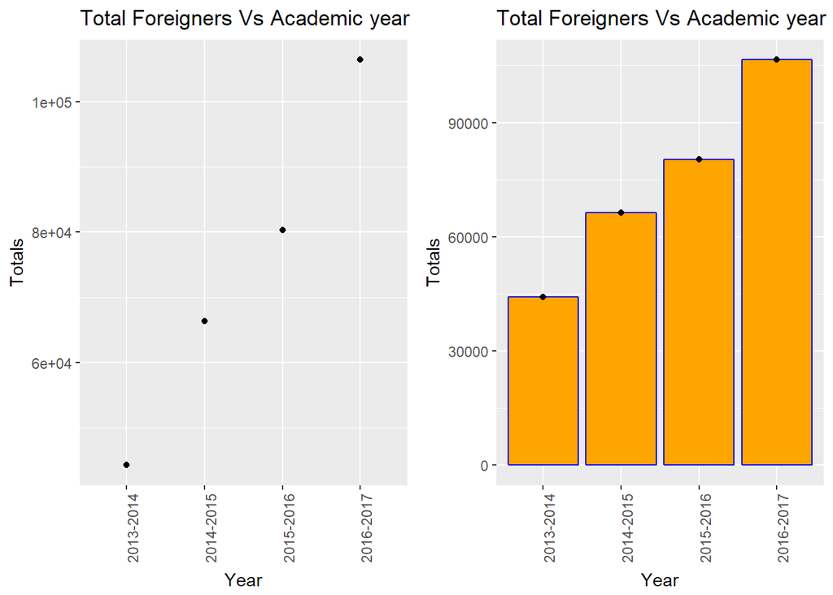

```r
p1 = ggplot(data=totalf, aes(x=Year, y=Totals)) +
      geom_line(stat="identity", color="blue", fill="Orange")+
      geom_point() +
      ggtitle( "Total Foreigners Vs Academic year")+
      theme(axis.text.x = element_text(angle = 90))
p2 = ggplot(data=totalf, aes(x=Year, y=Totals)) +
      geom_bar(stat="identity", color="blue", fill="Orange")+
      geom_point() +
      ggtitle( "Total Foreigners Vs Academic year")+
      theme(axis.text.x = element_text(angle = 90))
grid.arrange(p1, p2, ncol=2)
```

### Description One

From this graph it can easily be seen that: The total number of foreign students in Turkey is increasing linearly with time. It is expected to be well above 120,000 by the end of the 2017-2018 academic year

### Plot Two

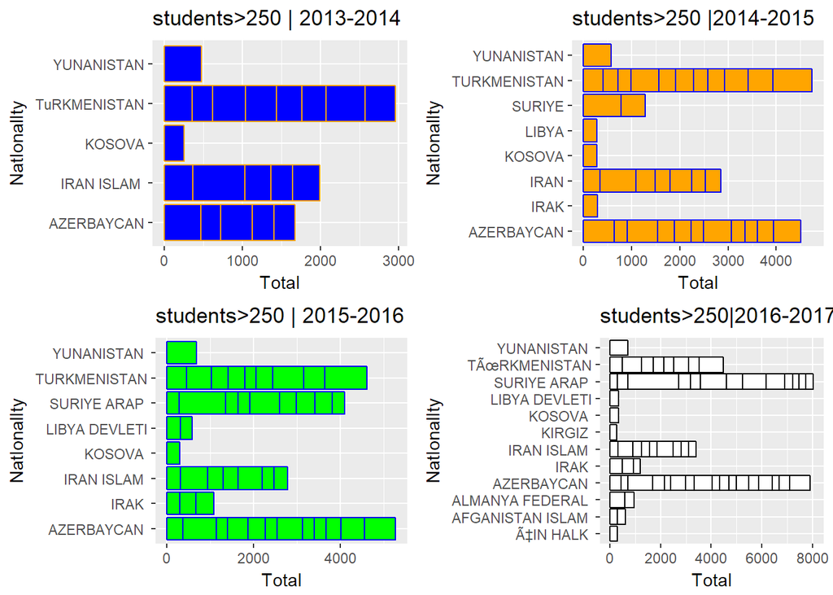

```r
p1 = ggplot(aes(x = NatIonalIty, y = Total),
      data = subset(f1314Totaless, (f1314Totaless$Total > 250))) +
      geom_histogram(stat = 'identity', color = "orange", fill = "blue") +
      coord_flip() +
      ggtitle("students>250 | 2013-2014")
p2 = ggplot(aes(x=NatIonalIty, y=Total),
      data = subset(f1415Totaless, (f1415Totaless$Total>250) )) +
      geom_histogram(stat = 'identity', color="blue", fill="orange") +
      coord_flip()+
      ggtitle("students>250 |2014-2015")
p3 = ggplot(aes(x=NatIonalIty, y=Total),
      data = subset(f1516Totaless, (f1516Totaless$Total>250) )) +
      geom_histogram(stat = 'identity', color="blue", fill="green") +
      coord_flip() + #theme(axis.text.x = element_text(angle = 90))+
      ggtitle("students>250 | 2015-2016")
p4 = ggplot(aes(x=NatIonalIty, y=Total),
      data = subset(f1617Totaless, (f1617Totaless$Total>250) )) +
      geom_histogram(stat = 'identity', color="black", fill="white") +
      coord_flip() +
      ggtitle("students>250|2016-2017")
library(gridExtra)
grid.arrange(p1, p2, p3, p4, nrow = 2)
```

### Description Two

Turkmenistan and Azerbaycan had the biggest count of foreigners before 2016. But after that point, Syria had the biggest number of foreign students. Closely followed by Azerbaycan

Almost doubling that of Turkmenistan - the third largest. The shift in numbers is not surprising really after the recent geopolitical occurencies in Syrica and treaties signed with Azerbaycan.

### Plot Three

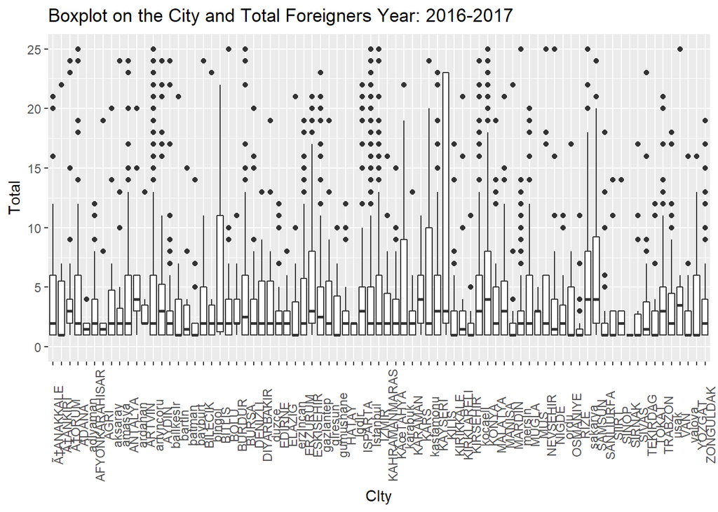

```r
qplot(x = CIty , y = Total , data = f1617Totaless,
  geom = 'boxplot' , main = 'Boxplot on the City and Total Foreigners Year: 2016-2017')+
  scale_y_continuous(limits = c(0,25))+
  theme(axis.text.x = element_text(angle = 90))
```

# Reflection

In this study an analysis was carried out on the variation of foreign student number over time in Turkey. A relation between the total number of foreign students and time was successfully found. Furthermore, the countries where they mainly come from, the cities in Turkey they go to and, consequently, the universities that they mainly/are likely to join. 1. cleaning the data was a very time intensive task - took over 50% of the entire project time. 2. Choosing the right graph types and functions for data display was no easy feat. 3. The fact that new universities are founded over time made the analysis more difficult as it required creating of new datasets